# MIE1624-Integration Workbook-2017-04-02

### Number of Ratings by Time Period

Overall, the number of ratings increases rapidly in the past 4 years.

The peak for each year is at Q3 (July - September)

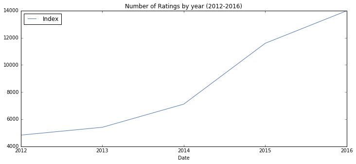

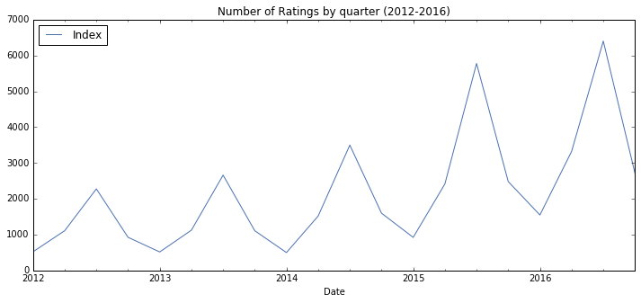

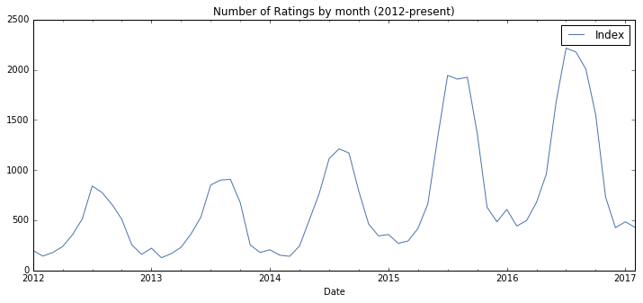

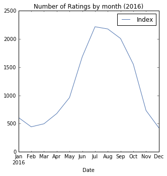

```python
df2.loc['2012':'2016'].resample('A').count()[[0]].plot(figsize = (12,5),\
                                                 title = 'Number of Ratings by year (2012-2016)')

df2.loc['2012':'2016'].resample('Q').count()[[0]].plot(figsize = (12,5),\
                                                 title = 'Number of Ratings by quarter (2012-2016)')

df2.loc['jan 01 2012':'feb 28 2017'].resample('M').count()[[0]].plot(figsize = (12,5),\
                                                 title = 'Number of Ratings by month (2012-present)')

df2.loc['2016'].resample('M').count()[[0]].plot(figsize = (5,5),\
                                                 title = 'Number of Ratings by month (2016)')
```

[output not shown]

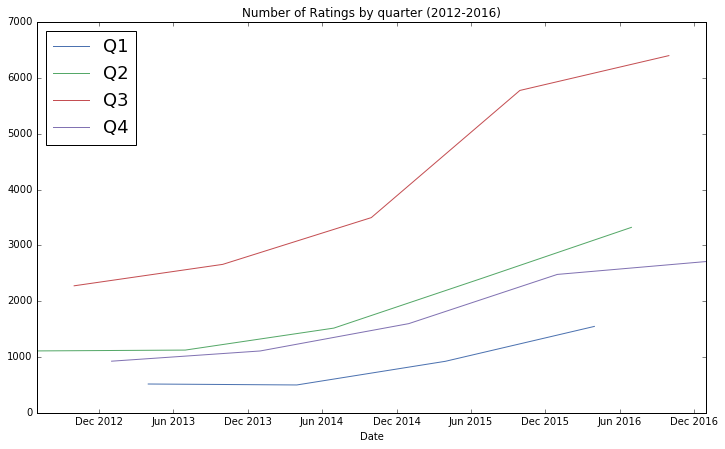

```python
plt.rcParams["figure.figsize"] = (12,7)
plt.plot(df2.loc['2012':'2016'].resample('Q').count()[[1]].iloc[4::4], label = 'Q1')
plt.plot(df2.loc['2012':'2016'].resample('Q').count()[[1]].iloc[1::4], label = 'Q2')
plt.plot(df2.loc['2012':'2016'].resample('Q').count()[[1]].iloc[2::4], label = 'Q3')
plt.plot(df2.loc['2012':'2016'].resample('Q').count()[[1]].iloc[3::4], label = 'Q4')
plt.title('Number of Ratings by quarter (2012-2016)')
plt.xlabel('Date')
plt.legend(loc='upper left', numpoints = 1, prop={'size':18})
plt.plot(plotsize=(14,10))
plt.show()
```

### Number of Reviews per Time Period and Attractions

Now we look at some specific attractions: CN Tower, Notre-Dame Basilica and the Air Canada Center.

The first two attractions have more ratings during summer times than winter.

As for air canada center, it is an indoor attraction, so this trend does not exist.

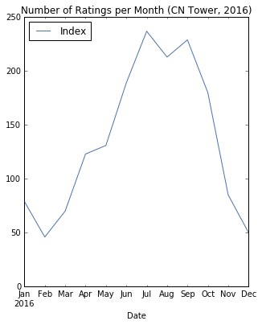

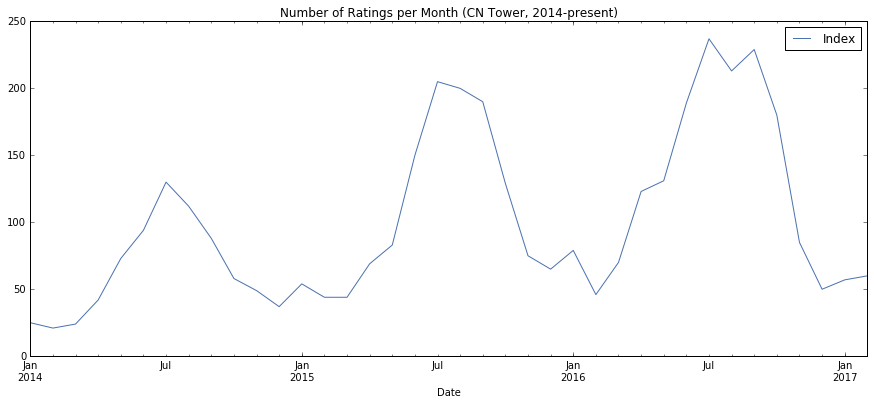

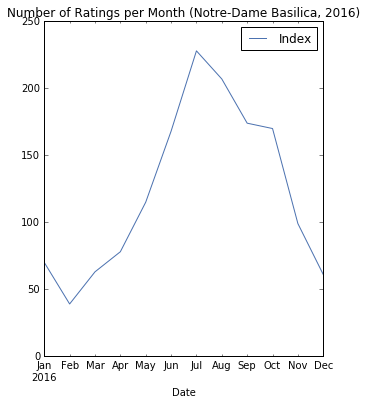

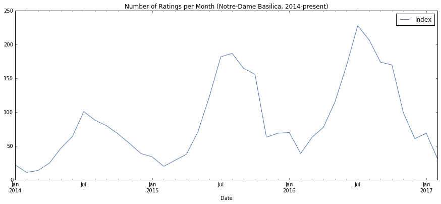

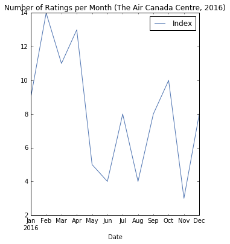

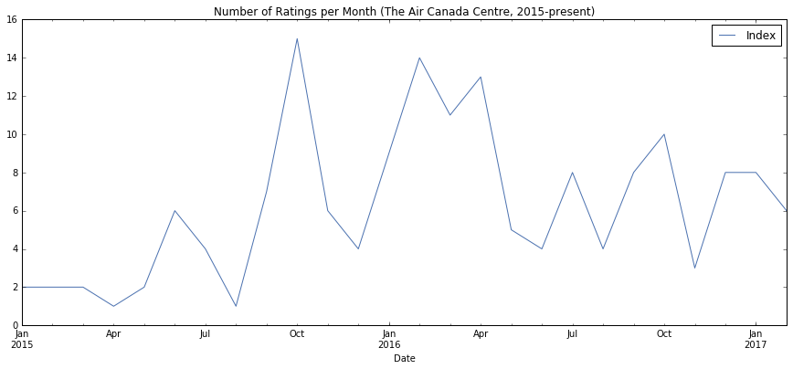

```python
df2.loc[df2['Attraction'] == 'CN Tower'].loc['2016'].resample('M').count()[[0]].plot(figsize=(5,6), \
                                                 title = 'Number of Ratings per Month (CN Tower, 2016)')

df2.loc[df2['Attraction'] == 'CN Tower'].loc['jan 01 2014':'feb 28 2017'].resample('M').count()[[0]].plot(figsize = (15,6),\
                                                 title = 'Number of Ratings per Month (CN Tower, 2014-present)')

df2.loc[df2['Attraction'] == 'Notre-Dame Basilica'].loc['2016'].resample('M').count()[[0]].plot(figsize=(5,6), \
                                                 title = 'Number of Ratings per Month (Notre-Dame Basilica, 2016)')

df2.loc[df2['Attraction'] == 'Notre-Dame Basilica'].loc['jan 01 2014':'feb 28 2017'].resample('M').count()[[0]].plot(figsize = (15,6),\
                                                 title = 'Number of Ratings per Month (Notre-Dame Basilica, 2014-present)')

df2.loc[df2['Attraction'] == 'The Air Canada Centre'].loc['2016'].resample('M').count()[[0]].plot(figsize=(5,6), \
                                                 title = 'Number of Ratings per Month (The Air Canada Centre, 2016)')

df2.loc[df2['Attraction'] == 'The Air Canada Centre'].loc['jan 01 2015':'feb 28 2017'].resample('M').count()[[0]].plot(figsize=(15,6), \
                                                 title = 'Number of Ratings per Month (The Air Canada Centre, 2015-present)')
```

## Sentiment Analysis

```python
import matplotlib.pyplot as plt
%matplotlib inline
import pandas as pd
import numpy as np
import math
#Download required ntlk packages and lib
!pip --quiet install nltk
import nltk
nltk.download("vader_lexicon")
nltk.download("stopwords")
from nltk.sentiment import SentimentAnalyzer
from nltk.sentiment.vader import SentimentIntensityAnalyzer
from nltk.sentiment.util import *
from nltk import tokenize
from nltk.corpus import stopwords
sid = SentimentIntensityAnalyzer()
```

```python
attraction_df = pd.read_csv('attraction.csv')
attraction_list = []
for index, row in attraction_df.iterrows():
    attraction_list.append([row['Location']]+[row['ReviewText']]+[row['Rating']]+[row['Attraction']]+['positive' if row['Rating'] > 3 else 'negative'])
attraction_df = pd.DataFrame(attraction_list)
attraction_df.columns=['Review_Location','Review','Rating','Attraction','GroundTruth']
```

```python
stop = set(stopwords.words('english'))
stop.add('see')
stop.add('falls')
stop.add('tower')
stop.add('city')
stop.add('get')
```

```python
attractions = attraction_df['Review'].as_matrix()
#Count the frequency of words
from collections import Counter
import re
counter = Counter()
for attraction in attractions:
        counter.update([word.lower() for word in re.findall(r'\w+', attraction) if word.lower() not in stop and len(word) > 2])
k = 500
topk = counter.most_common(k)
```

```python
pdlist = []
#Assign Vader score to individual review using Vader compound score
for rownum, attraction in enumerate(attractions):
    ss = sid.polarity_scores(attraction)
    pdlist.append([attraction]+[ss['compound']])
    if (rownum % 5000 == 1):
            print("processed %d reviews" % (rownum+1))
```

```
processed 2 reviews
processed 5002 reviews
processed 10002 reviews
processed 15002 reviews
processed 20002 reviews
processed 25002 reviews
processed 30002 reviews
processed 35002 reviews
processed 40002 reviews
processed 45002 reviews
```

```python
reviewDf = pd.DataFrame(pdlist)
reviewDf.columns = ['reviewCol','vader']
#Find out if a particular review has the word from topk list
freqReview = []
for i in range(len(reviewDf)):
    tempCounter = Counter([word.lower() for word in re.findall(r'\w+',reviewDf['reviewCol'][i])])
    topkinReview = [1 if tempCounter[word] > 0 else 0 for (word,wordCount) in topk]
    freqReview.append(topkinReview)
#Prepare freqReviewDf
freqReviewDf = pd.DataFrame(freqReview)
dfName = []
for c in topk:
    dfName.append(c[0])
freqReviewDf.columns = dfName
```

```python
finalreviewDf = reviewDf.join(freqReviewDf)
finaldf = attraction_df[['Review_Location','Attraction','Rating','GroundTruth']].join(finalreviewDf)
```

### Find most sentimental words by Mutual Information

The Mutual Information is a measure of the similarity between two labels of the same data.

```python
gtScore = []
for i in range(len(finaldf)):
    if finaldf['Rating'][i]>3:
        gtScore.append(1)
    else:
        gtScore.append(0)
```

```python
#Calculate muual information score using scikit lean package
import sklearn
import sklearn.metrics as metrics
miScore = []
for word in topk:
    miScore.append([word[0]]+[metrics.mutual_info_score(gtScore,finaldf[word[0]].as_matrix())])
miScoredf = pd.DataFrame(miScore).sort_values(1,ascending=0)
miScoredf.columns = ['Word','MI Score']
miScoredf.head(20)
```

|  | Word | MI Score |
| --- | --- | --- |
| 244 | nothing | 0.004772 |
| 1 | beautiful | 0.004218 |
| 15 | amazing | 0.004050 |
| 137 | expensive | 0.003075 |
| 331 | disappointed | 0.002494 |
| 18 | must | 0.002340 |
| 62 | loved | 0.001986 |
| 108 | tourist | 0.001918 |
| 27 | would | 0.001826 |
| 0 | great | 0.001816 |
| 55 | wonderful | 0.001795 |
| 28 | much | 0.001709 |
| 166 | however | 0.001575 |
| 349 | closed | 0.001379 |
| 14 | nice | 0.001348 |
| 19 | side | 0.001312 |
| 95 | mist | 0.001296 |
| 130 | pretty | 0.001279 |
| 88 | bit | 0.001253 |
| 168 | stunning | 0.001153 |

### PMI for Positive and Negative

Similar to MI, PMI is measuring for sigle event where MI is the average of all possible event. The events P(x,y) = P(0,1) means the event of the review is negative but the specific word is existing in that review

```python
#Obtain finaldf again for PMI, it should be same as the finaldf before. But just tobe safe, we retrieve it again
freqReview = []
for i in range(len(reviewDf)):
    tempCounter = Counter([word.lower() for word in re.findall(r'\w+',reviewDf['reviewCol'][i])])
    topkinReview = [1 if tempCounter[word] > 0 else 0 for (word,wordCount) in topk]
    freqReview.append(topkinReview)
freqReviewDf = pd.DataFrame(freqReview)
dfName = []
for c in topk:
    dfName.append(c[0])
freqReviewDf.columns = dfName
finalreviewDf = reviewDf.join(freqReviewDf)
finaldf = attraction_df[['Attraction','Rating','GroundTruth']].join(finalreviewDf)
finaldf
```

|  | Attraction | Rating | GroundTruth | reviewCol | vader | great | beautiful | visit | place | time | ... | favorite | anyone | rocks | wow | foods | either | lucky | use | feeling | frontenac |
| --- | --- | --- | --- | --- | --- | --- | --- | --- | --- | --- | --- | --- | --- | --- | --- | --- | --- | --- | --- | --- | --- |
| 0 | Assiniboine Park | 5 | positive | Speaking the day with grandson taking in the p... | 0.5574 | 0 | 0 | 0 | 0 | 1 | ... | 0 | 0 | 0 | 0 | 0 | 0 | 0 | 0 | 0 | 0 |
| 1 | Assiniboine Park | 3 | negative | We spent no too much time there, the park is n... | 0.2263 | 0 | 0 | 0 | 1 | 1 | ... | 0 | 0 | 0 | 0 | 0 | 0 | 0 | 0 | 0 | 0 |
| 2 | Assiniboine Park | 5 | positive | The park was clean and well kept as far that I... | 0.8748 | 0 | 1 | 0 | 0 | 0 | ... | 0 | 0 | 0 | 0 | 0 | 0 | 0 | 0 | 0 | 0 |
| 3 | Assiniboine Park | 4 | positive | We had a few days to kill in Winnipeg prior to... | -0.4576 | 0 | 0 | 0 | 0 | 0 | ... | 0 | 0 | 0 | 0 | 0 | 0 | 0 | 0 | 0 | 0 |
| 4 | Assiniboine Park | 5 | positive | Nice zoo with great enclosures that simulate t... | 0.9246 | 1 | 0 | 0 | 0 | 0 | ... | 0 | 0 | 0 | 0 | 0 | 0 | 0 | 0 | 0 | 0 |
| 5 | Assiniboine Park | 4 | positive | Spacious lawns and so much to see and do. Our ... | 0.7783 | 0 | 0 | 1 | 0 | 1 | ... | 0 | 0 | 0 | 0 | 0 | 0 | 0 | 0 | 0 | 0 |
| 6 | Assiniboine Park | 5 | positive | The walk through tunnel that run through the p... | 0.6281 | 0 | 0 | 0 | 0 | 0 | ... | 0 | 0 | 0 | 0 | 0 | 0 | 0 | 0 | 0 | 0 |
| 7 | Assiniboine Park | 5 | positive | We were enroute to Churchill to visit the pola... | 0.4215 | 0 | 0 | 1 | 0 | 0 | ... | 0 | 0 | 0 | 0 | 0 | 0 | 0 | 0 | 0 | 0 |
| 8 | Assiniboine Park | 5 | positive | We were very lucky to have perfect weather to ... | 0.9371 | 0 | 0 | 0 | 0 | 0 | ... | 0 | 0 | 0 | 0 | 0 | 0 | 1 | 0 | 0 | 0 |
| 9 | Assiniboine Park | 4 | positive | We spent the day around the park. The highligh... | 0.9169 | 1 | 0 | 0 | 0 | 0 | ... | 0 | 0 | 0 | 0 | 0 | 0 | 0 | 0 | 0 | 0 |
| 10 | Assiniboine Park | 5 | positive | We visited the English Garden and Sculptures. ... | 0.9438 | 0 | 1 | 1 | 1 | 0 | ... | 0 | 0 | 0 | 0 | 0 | 0 | 0 | 0 | 0 | 0 |
| 11 | Assiniboine Park | 5 | positive | A very nice park. Theyhave done a great job ad... | 0.9379 | 1 | 0 | 0 | 0 | 0 | ... | 0 | 0 | 0 | 0 | 0 | 0 | 0 | 0 | 0 | 0 |
| 12 | Assiniboine Park | 4 | positive | A bridage over the river, gardens, trees, and ... | 0.5859 | 0 | 0 | 0 | 0 | 0 | ... | 0 | 0 | 0 | 0 | 0 | 0 | 0 | 0 | 0 | 0 |
| 13 | Assiniboine Park | 5 | positive | Lovely walkways, nice trails, fantastic sculpt... | 0.8807 | 0 | 0 | 0 | 0 | 0 | ... | 0 | 0 | 0 | 0 | 0 | 0 | 0 | 0 | 0 | 0 |
| 14 | Assiniboine Park | 5 | positive | We enjoyed this park. There were many animals ... | 0.9125 | 0 | 0 | 0 | 0 | 1 | ... | 0 | 0 | 0 | 0 | 0 | 0 | 0 | 0 | 0 | 0 |
| 15 | Assiniboine Park | 5 | positive | Spent most of our one full day in Winnipeg at ... | 0.9099 | 0 | 0 | 0 | 0 | 0 | ... | 0 | 0 | 0 | 0 | 0 | 0 | 0 | 0 | 0 | 0 |
| 16 | Assiniboine Park | 5 | positive | Polar bears exhibit was worth the hype. Saw th... | 0.7344 | 0 | 0 | 0 | 0 | 0 | ... | 0 | 0 | 0 | 0 | 0 | 0 | 0 | 0 | 0 | 0 |
| 17 | Assiniboine Park | 5 | positive | We found parking very easy, our destination: T... | 0.9371 | 0 | 1 | 0 | 0 | 0 | ... | 0 | 0 | 0 | 0 | 0 | 0 | 0 | 0 | 0 | 0 |
| 18 | Assiniboine Park | 4 | positive | Very nice to have some great outdoor space to ... | 0.9447 | 1 | 0 | 0 | 0 | 0 | ... | 0 | 0 | 0 | 0 | 0 | 0 | 0 | 0 | 0 | 0 |
| 19 | Assiniboine Park | 5 | positive | Rent one of the double surries! Super fun way ... | 0.9468 | 1 | 0 | 0 | 0 | 0 | ... | 0 | 0 | 0 | 0 | 0 | 1 | 0 | 0 | 0 | 0 |
| 20 | Assiniboine Park | 4 | positive | Large open spaces, playgrounds, sculptures, ru... | 0.0000 | 0 | 0 | 0 | 0 | 0 | ... | 0 | 0 | 0 | 0 | 0 | 0 | 0 | 0 | 0 | 0 |
| 21 | Assiniboine Park | 5 | positive | We only visited Nature Playground while at Ass... | 0.9231 | 0 | 0 | 0 | 0 | 1 | ... | 0 | 0 | 0 | 0 | 0 | 0 | 0 | 0 | 0 | 0 |
| 22 | Assiniboine Park | 5 | positive | What a beautiful park. We couldn't believe how... | 0.5106 | 0 | 1 | 0 | 0 | 0 | ... | 0 | 0 | 0 | 0 | 0 | 0 | 0 | 0 | 0 | 0 |
| 23 | Assiniboine Park | 5 | positive | Had a great time at the park. I always admire ... | 0.8020 | 1 | 0 | 0 | 0 | 1 | ... | 0 | 0 | 0 | 0 | 0 | 0 | 0 | 0 | 0 | 0 |
| 24 | Assiniboine Park | 4 | positive | Congratulations to the City of Winnipeg for th... | 0.9517 | 0 | 1 | 1 | 0 | 0 | ... | 0 | 0 | 0 | 0 | 0 | 0 | 0 | 0 | 0 | 0 |
| 25 | Assiniboine Park | 5 | positive | A large park to enjoy a nice relaxing day with... | 0.9584 | 0 | 0 | 1 | 0 | 0 | ... | 0 | 0 | 0 | 0 | 0 | 0 | 0 | 0 | 0 | 0 |
| 26 | Assiniboine Park | 5 | positive | Traveled here with family during the Winter an... | 0.8300 | 0 | 0 | 0 | 0 | 0 | ... | 0 | 0 | 0 | 0 | 0 | 0 | 0 | 0 | 0 | 0 |
| 27 | Assiniboine Park | 5 | positive | Being new to Winnipeg from the Midwest, this w... | 0.9421 | 1 | 0 | 0 | 1 | 0 | ... | 0 | 0 | 0 | 0 | 0 | 0 | 0 | 0 | 0 | 0 |
| 28 | Assiniboine Park | 4 | positive | We enjoyed our visit to this zoo while in Winn... | 0.8442 | 0 | 0 | 1 | 0 | 0 | ... | 0 | 0 | 0 | 0 | 0 | 0 | 0 | 0 | 0 | 0 |
| 29 | Assiniboine Park | 5 | positive | The volunteers were great! Enjoyed the exhibit... | 0.8858 | 1 | 0 | 0 | 0 | 0 | ... | 0 | 0 | 0 | 0 | 0 | 0 | 0 | 0 | 0 | 0 |
| ... | ... | ... | ... | ... | ... | ... | ... | ... | ... | ... | ... | ... | ... | ... | ... | ... | ... | ... | ... | ... | ... |
| 45432 | Yukon Wildlife Preserve | 5 | positive | I greatly enjoyed the peaceful, pretty walk ar... | 0.9860 | 0 | 0 | 0 | 0 | 0 | ... | 0 | 0 | 0 | 0 | 0 | 0 | 0 | 0 | 0 | 0 |
| 45433 | Yukon Wildlife Preserve | 4 | positive | We did this as part of a bus tour. When we arr... | 0.0000 | 0 | 0 | 0 | 0 | 0 | ... | 0 | 0 | 0 | 0 | 0 | 0 | 0 | 0 | 0 | 0 |
| 45434 | Yukon Wildlife Preserve | 4 | positive | A lovely place to spend time being driven arou... | 0.8190 | 0 | 0 | 0 | 1 | 1 | ... | 0 | 0 | 0 | 0 | 0 | 0 | 0 | 0 | 0 | 0 |
| 45435 | Yukon Wildlife Preserve | 4 | positive | Took the 90 min bus tour and enjoyed the guide... | 0.5106 | 0 | 0 | 0 | 0 | 0 | ... | 0 | 0 | 0 | 0 | 0 | 0 | 0 | 0 | 0 | 0 |
| 45436 | Yukon Wildlife Preserve | 4 | positive | Our trip into the Yukon included a stop into t... | -0.2960 | 0 | 0 | 0 | 0 | 0 | ... | 0 | 0 | 0 | 0 | 0 | 0 | 0 | 0 | 0 | 0 |
| 45437 | Yukon Wildlife Preserve | 4 | positive | We spent a few hours there. The area was much ... | 0.8519 | 0 | 1 | 0 | 0 | 0 | ... | 0 | 0 | 0 | 0 | 0 | 0 | 0 | 0 | 0 | 0 |
| 45438 | Yukon Wildlife Preserve | 5 | positive | Visiting the Wildlife Preserve in winter is an... | 0.8807 | 0 | 0 | 0 | 1 | 0 | ... | 0 | 0 | 0 | 0 | 0 | 0 | 0 | 0 | 0 | 0 |
| 45439 | Yukon Wildlife Preserve | 4 | positive | If you have nothing else to do... then go visi... | 0.5994 | 0 | 0 | 1 | 0 | 0 | ... | 0 | 0 | 0 | 0 | 0 | 0 | 0 | 0 | 0 | 0 |
| 45440 | Yukon Wildlife Preserve | 5 | positive | Unlike a zoo, these animals are allowed to roa... | 0.6114 | 0 | 0 | 0 | 0 | 0 | ... | 0 | 0 | 0 | 0 | 0 | 0 | 1 | 0 | 0 | 0 |
| 45441 | Yukon Wildlife Preserve | 4 | positive | We walked a figure eight trail of approximatel... | 0.8984 | 0 | 0 | 0 | 0 | 0 | ... | 0 | 0 | 0 | 0 | 0 | 0 | 1 | 0 | 0 | 0 |
| 45442 | Yukon Wildlife Preserve | 4 | positive | A nice very open facility on what was once a r... | 0.7430 | 1 | 0 | 0 | 0 | 0 | ... | 0 | 0 | 0 | 0 | 0 | 0 | 0 | 0 | 0 | 0 |
| 45443 | Yukon Wildlife Preserve | 4 | positive | Interesting introduction to the wildlife in an... | 0.5411 | 0 | 0 | 0 | 0 | 0 | ... | 0 | 0 | 0 | 0 | 0 | 0 | 0 | 0 | 0 | 0 |
| 45444 | Yukon Wildlife Preserve | 5 | positive | As we had to travel via vehicle through this h... | 0.8534 | 1 | 0 | 0 | 0 | 0 | ... | 0 | 0 | 0 | 0 | 0 | 0 | 0 | 0 | 0 | 0 |
| 45445 | Yukon Wildlife Preserve | 4 | positive | just in case you don't have wildlife adventure... | 0.2890 | 0 | 0 | 1 | 0 | 0 | ... | 0 | 0 | 0 | 0 | 0 | 0 | 0 | 0 | 0 | 0 |
| 45446 | Yukon Wildlife Preserve | 5 | positive | Nicely laid out, animals in their habitat. The... | 0.9125 | 0 | 0 | 0 | 0 | 0 | ... | 0 | 0 | 0 | 0 | 0 | 0 | 0 | 0 | 0 | 0 |
| 45447 | Yukon Wildlife Preserve | 4 | positive | I enjoyed stopping by here during our stay at ... | 0.8322 | 0 | 0 | 0 | 0 | 0 | ... | 0 | 0 | 0 | 0 | 0 | 0 | 0 | 0 | 0 | 0 |
| 45448 | Yukon Wildlife Preserve | 5 | positive | We took relatives from out of town to the Wild... | 0.8118 | 0 | 1 | 0 | 0 | 1 | ... | 0 | 0 | 0 | 0 | 0 | 0 | 0 | 0 | 0 | 0 |
| 45449 | Yukon Wildlife Preserve | 4 | positive | Great tour with very interesting animals, part... | 0.9216 | 1 | 0 | 0 | 0 | 0 | ... | 0 | 0 | 0 | 0 | 0 | 0 | 0 | 0 | 0 | 0 |
| 45450 | Yukon Wildlife Preserve | 4 | positive | Nice tour with an introduction to several indi... | 0.8687 | 0 | 0 | 0 | 0 | 0 | ... | 0 | 0 | 0 | 0 | 0 | 0 | 0 | 0 | 0 | 0 |
| 45451 | Yukon Wildlife Preserve | 5 | positive | Our tour guide was excellent and made every ef... | 0.7506 | 0 | 0 | 0 | 0 | 0 | ... | 0 | 0 | 0 | 0 | 0 | 0 | 0 | 0 | 0 | 0 |
| 45452 | Yukon Wildlife Preserve | 5 | positive | great tour as only paying customers so park vo... | 0.9153 | 1 | 0 | 0 | 0 | 0 | ... | 0 | 0 | 0 | 0 | 0 | 0 | 0 | 0 | 0 | 0 |
| 45453 | Yukon Wildlife Preserve | 5 | positive | We liked the fact that the animals were in nat... | 0.3919 | 0 | 0 | 0 | 0 | 0 | ... | 0 | 0 | 0 | 0 | 0 | 0 | 0 | 0 | 0 | 0 |
| 45454 | Yukon Wildlife Preserve | 5 | positive | This preserve is a great place to see the wild... | 0.8180 | 1 | 0 | 0 | 1 | 0 | ... | 0 | 0 | 0 | 0 | 0 | 0 | 0 | 0 | 0 | 0 |
| 45455 | Yukon Wildlife Preserve | 5 | positive | A great setting to take a walk and view wildli... | 0.7506 | 1 | 0 | 0 | 0 | 0 | ... | 0 | 0 | 0 | 0 | 0 | 0 | 0 | 0 | 0 | 0 |
| 45456 | Yukon Wildlife Preserve | 5 | positive | It was great to see so many interesting animal... | 0.8952 | 1 | 0 | 0 | 0 | 0 | ... | 0 | 0 | 0 | 0 | 0 | 0 | 0 | 0 | 0 | 0 |
| 45457 | Yukon Wildlife Preserve | 4 | positive | Interesting animals, knowledgeable guide. Take... | 0.4019 | 0 | 0 | 0 | 0 | 0 | ... | 0 | 0 | 0 | 0 | 0 | 0 | 0 | 0 | 0 | 0 |
| 45458 | Yukon Wildlife Preserve | 5 | positive | Really enjoyed the Yukon Wildlife Preserve bus... | 0.9428 | 1 | 0 | 0 | 0 | 0 | ... | 0 | 0 | 0 | 0 | 0 | 0 | 0 | 0 | 0 | 0 |
| 45459 | Yukon Wildlife Preserve | 5 | positive | We were part of a small tour group thru Northe... | 0.8572 | 0 | 0 | 0 | 0 | 0 | ... | 0 | 0 | 0 | 0 | 0 | 0 | 0 | 0 | 0 | 0 |
| 45460 | Yukon Wildlife Preserve | 5 | positive | So worth the visit, especially to see animals ... | 0.2944 | 0 | 0 | 1 | 0 | 0 | ... | 0 | 0 | 0 | 0 | 0 | 0 | 0 | 0 | 0 | 0 |
| 45461 | Yukon Wildlife Preserve | 5 | positive | Take the guided tour -- the guide is friendly ... | 0.6486 | 0 | 0 | 0 | 0 | 0 | ... | 0 | 0 | 0 | 0 | 0 | 0 | 0 | 0 | 0 | 0 |

45462 rows × 505 columns

```python
def pmiCal(df, x):
    pmilist=[]
    for i in ['positive','negative']:
        for j in [0,1]:
            px = sum(finaldf['GroundTruth']==i)/len(df)
            py = sum(finaldf[x]==j)/len(df)
            pxy = len(finaldf[(finaldf['GroundTruth']==i) & (finaldf[x]==j)])/len(df)
            if pxy==0:#Log 0 cannot happen
                pmi = math.log10((pxy+0.0001)/(px*py))
            else:
                pmi = math.log10(pxy/(px*py))
            pmilist.append([i]+[j]+[px]+[py]+[pxy]+[pmi])
    pmidf = pd.DataFrame(pmilist)
    pmidf.columns = ['x','y','px','py','pxy','pmi']
    return pmidf
```

```python
pmiCal(finaldf,'fall')
```

|  | x | y | px | py | pxy | pmi |
| --- | --- | --- | --- | --- | --- | --- |
| 0 | positive | 0 | 0.908781 | 0.987528 | 0.896969 | -0.000231 |
| 1 | positive | 1 | 0.908781 | 0.012472 | 0.011812 | 0.017932 |
| 2 | negative | 0 | 0.091219 | 0.987528 | 0.090559 | 0.002297 |
| 3 | negative | 1 | 0.091219 | 0.012472 | 0.000660 | -0.236547 |

```python
#Calculate muual information score using scikit lean package
import sklearn
import sklearn.metrics as metrics
pmiScore = []
for rownum,word in enumerate(topk):
    pmiScore.append([word[0]]+[pmiCal(finaldf,word[0])['pmi'][3]])
    if (rownum % 25 == 1):
        print("processed %d reviews" % (rownum+1))
pmiScoredf = pd.DataFrame(pmiScore).sort_values(1,ascending=0)
pmiScoredf.columns = ['Word','PMI Score']
pmiScoredf.head(20)
```

```
processed 2 reviews
processed 27 reviews
processed 52 reviews
processed 77 reviews
processed 102 reviews
processed 127 reviews
processed 152 reviews
processed 177 reviews
processed 202 reviews
processed 227 reviews
processed 252 reviews
processed 277 reviews
processed 302 reviews
processed 327 reviews
processed 352 reviews
processed 377 reviews
processed 402 reviews
processed 427 reviews
processed 452 reviews
processed 477 reviews
```

|  | Word | PMI Score |
| --- | --- | --- |
| 244 | nothing | 0.606845 |
| 331 | disappointed | 0.538286 |
| 430 | else | 0.459293 |
| 349 | closed | 0.453529 |
| 137 | expensive | 0.448143 |
| 397 | souvenir | 0.433077 |
| 474 | paid | 0.427131 |
| 480 | bad | 0.426084 |
| 417 | expected | 0.422471 |
| 302 | gastown | 0.401425 |
| 293 | special | 0.387760 |
| 166 | however | 0.364967 |
| 235 | money | 0.362800 |
| 435 | yes | 0.358902 |
| 309 | calgary | 0.352744 |
| 108 | tourist | 0.351322 |
| 216 | price | 0.349667 |
| 269 | clock | 0.345647 |
| 334 | vancouver | 0.342618 |
| 416 | anything | 0.330844 |

### Select top reviewed attraction 'Niagra Falls' to extract top PMI words maybe 20 words so we can see why people like it so much

```python
niagarafalls_df = finaldf.loc[finaldf['Attraction'] == 'Niagara Falls']
```

```python
pmiScore = []
for rownum,word in enumerate(topk):
    pmiScore.append([word[0]]+[pmiCal(niagarafalls_df,word[0])['pmi'][1]])
    if (rownum % 25 == 1):
        print("processed %d reviews" % (rownum+1))
pmiScoredf = pd.DataFrame(pmiScore).sort_values(1,ascending=0)
pmiScoredf.columns = ['Word','PMI Score']
pmiScoredf.head(20)
```

```
processed 2 reviews
processed 27 reviews
processed 52 reviews
processed 77 reviews
processed 102 reviews
processed 127 reviews
processed 152 reviews
processed 177 reviews
processed 202 reviews
processed 227 reviews
processed 252 reviews
processed 277 reviews
processed 302 reviews
processed 327 reviews
processed 352 reviews
processed 377 reviews
processed 402 reviews
processed 427 reviews
processed 452 reviews
processed 477 reviews
```

|  | Word | PMI Score |
| --- | --- | --- |
| 370 | hornblower | -0.632436 |
| 337 | horseshoe | -0.633795 |
| 408 | awe | -0.633797 |
| 403 | fireworks | -0.633977 |
| 185 | breathtaking | -0.635605 |
| 168 | stunning | -0.636105 |
| 171 | absolutely | -0.637004 |
| 406 | chapel | -0.637147 |
| 499 | frontenac | -0.637485 |
| 236 | highly | -0.637785 |
| 233 | power | -0.637831 |
| 385 | breath | -0.638057 |
| 431 | stained | -0.638386 |
| 62 | loved | -0.638433 |
| 298 | perfect | -0.638511 |
| 212 | truly | -0.638670 |
| 120 | awesome | -0.638677 |
| 378 | tide | -0.638983 |
| 327 | magnificent | -0.639025 |
| 249 | sight | -0.639238 |

### Analysis Over All Items

```python
#We are only intereseted in this three column for overall analysis
itemAnalysisDf = finaldf[['reviewCol','GroundTruth','vader']]
```

```python
from collections import Counter
import re
#To find out the most frequent word in review when the ground truth is positive
counter = Counter()
for review in itemAnalysisDf.loc[itemAnalysisDf['GroundTruth']=='positive']['reviewCol']:
        counter.update([word.lower() for word in re.findall(r'\w+', review) if word.lower() not in stop and len(word) > 2])
```

```python
k=10
topkPos = counter.most_common(k)
topkPos
```

```
[('great', 9779),
 ('beautiful', 8125),
 ('visit', 7324),
 ('place', 6717),
 ('time', 6202),
 ('old', 5854),
 ('one', 5588),
 ('worth', 5580),
 ('day', 5523),
 ('walk', 5401)]
```

```python
from collections import Counter
import re
counter = Counter()
#To find out the most frequent word in review when the ground truth is negative
for review in itemAnalysisDf.loc[itemAnalysisDf['GroundTruth']=='negative']['reviewCol']:
        counter.update([word.lower() for word in re.findall(r'\w+', review) if word.lower() not in stop and len(word) > 2])
```

```python
k=10
topkNeg = counter.most_common(k)
topkNeg
```

```
[('nice', 694),
 ('view', 673),
 ('visit', 606),
 ('would', 593),
 ('place', 589),
 ('much', 571),
 ('area', 562),
 ('great', 559),
 ('time', 550),
 ('good', 545)]
```

```python
from collections import Counter
import re
counter = Counter()
#To find out the most frequent word in review when the vader score is positive
for review in itemAnalysisDf.loc[itemAnalysisDf['vader']>0]['reviewCol']:
        counter.update([word.lower() for word in re.findall(r'\w+', review) if word.lower() not in stop and len(word) > 2])
k=10
topk = counter.most_common(k)
topk
```

```
[('great', 10192),
 ('beautiful', 8311),
 ('visit', 7427),
 ('place', 6929),
 ('time', 6217),
 ('old', 5962),
 ('worth', 5880),
 ('one', 5619),
 ('day', 5548),
 ('view', 5495)]
```

```python
from collections import Counter
import re
counter = Counter()
#To find out the most frequent word in review when the vader score is negative
for review in itemAnalysisDf.loc[itemAnalysisDf['vader']<0]['reviewCol']:
        counter.update([word.lower() for word in re.findall(r'\w+', review) if word.lower() not in stop and len(word) > 2])
k=10
topk = counter.most_common(k)
topk
```

```
[('time', 397),
 ('one', 370),
 ('visit', 351),
 ('day', 282),
 ('walk', 281),
 ('place', 278),
 ('old', 260),
 ('around', 257),
 ('view', 253),
 ('went', 247)]
```

### Analysis per Item

```python
#Extract a list of attractions
attractions = finaldf['Attraction'].unique()
attractions
```

```
array(['Assiniboine Park', 'Bruce Peninsula National Park',
       "Bush Pilot's Monument", 'Caesars Windsor', 'Calgary Tower',
       'Canadian Museum for Human Rights ', 'Canadian Museum of History',
       'Canmore Museum and Geoscience Centre',
       'Caribou Crossing Trading Post', 'Casino Regina',
       'Cave and Basin National Historic Site', 'CN Tower',
       'Confederation Centre of the Arts',
       'Cypress Hills Interprovincial Park ', 'Devonshire Mall',
       'Diamond Tooth Gerties Gambling Hall',
       'Dr. Sun Yat-Sen Classical Chinese Garden ',
       'East Point Lighthouse', 'Emerald Lake', 'Emily Carr House',
       'Eskimo museum', 'Fort Calgary',
       'Fortress of Louisbourg National Historic Site', 'Gas Town',
       'Government House ', 'Grasslands National Park',
       'Halifax Central Library', 'Halifax Public Gardens',
       'Hopewell Rocks', 'Jean-Talon Market', 'Lake Ontario',
       'Legislative Assembly of Nunavut', 'MacBride Museum',
       'McGill University', 'Miles Canyon',
       'Montmorency Falls Park (Parc de la Chute-Montmorency)',
       'Montreal Metro', 'Niagara Falls', 'Norstead Viking Village',
       'Northern Frontier Visitors Center', 'Notre-Dame Basilica',
       'Nunatta Sunakkutaangit Museum', 'Old Montreal', 'Old Quebec',
       'Old Town', 'Olympic Park (Parc olympique)',
       'Parliament Building (Hotel du Parlement)',
       'Parliament Hill and Buildings',
       'Prince of Wales Northern Heritage Centre', 'Royal Ontario Museum',
       'S.S. Kondike', 'Saint John City Market', 'Scarborough Bluffs',
       'Sign Post Forest', 'Signal Hill', "St. Dunstan's Basilica",
       'St. Lawrence Market', 'Stephen Avenue Walk', 'Stratford Festival',
       'Takhini Hot Springs', 'Terrasse Dufferin', 'The Air Canada Centre',
       'The Legislative Assembly Building', 'Toronto Islands',
       'Underground City', 'Unikkaarvik Visitor Centre',
       'University of Toronto', 'Wascana Centre Park',
       'Western Development Museum', 'Whistler Museum',
       'Windsor Riverfront', 'Winnipeg Art Gallery', 'Wreck Beach',
       'Yorkville', 'Yukon Beringia Interpretive Centre',
       'Yukon Visitor Information Centre', 'Yukon Wildlife Preserve'], dtype=object)
```

```python
#Rank by ground truth rating score
attractionRating = []
for attraction in attractions:
    itemDf = finaldf.loc[finaldf['Attraction']==attraction]
    attractionRating.append([attraction,itemDf['Rating'].mean()])
attractionRatingDfGt = pd.DataFrame(attractionRating)
attractionRatingDfGt.columns=['Attraction','avgRatingScore']
attractionRatingDfGt.sort_values('avgRatingScore',ascending=0).head(10)
```

|  | Attraction | avgRatingScore |
| --- | --- | --- |
| 31 | Legislative Assembly of Nunavut | 5.000000 |
| 26 | Halifax Central Library | 4.883117 |
| 37 | Niagara Falls | 4.815635 |
| 58 | Stratford Festival | 4.811189 |
| 43 | Old Quebec | 4.805029 |
| 18 | Emerald Lake | 4.765625 |
| 67 | Wascana Centre Park | 4.757576 |
| 28 | Hopewell Rocks | 4.748996 |
| 75 | Yukon Visitor Information Centre | 4.684932 |
| 40 | Notre-Dame Basilica | 4.683352 |

```python
#Rank the attraction by ground truth rating score
attractionRating = []
for attraction in attractions:
    itemDf = finaldf.loc[finaldf['Attraction']==attraction]
    attractionRating.append([attraction,itemDf['vader'].mean()])
attractionRatingDfVd = pd.DataFrame(attractionRating)
attractionRatingDfVd.columns=['Attraction','avgRatingScore']
attractionRatingDfVd.sort_values('avgRatingScore',ascending=0).head(10)
```

|  | Attraction | avgRatingScore |
| --- | --- | --- |
| 41 | Nunatta Sunakkutaangit Museum | 0.947775 |
| 65 | Unikkaarvik Visitor Centre | 0.898800 |
| 17 | East Point Lighthouse | 0.808743 |
| 27 | Halifax Public Gardens | 0.802116 |
| 70 | Windsor Riverfront | 0.793032 |
| 58 | Stratford Festival | 0.791283 |
| 55 | St. Dunstan's Basilica | 0.774064 |
| 67 | Wascana Centre Park | 0.771679 |
| 62 | The Legislative Assembly Building | 0.770009 |
| 19 | Emily Carr House | 0.765963 |

### Plots Comparing Groundtruth and Vader

```python
import matplotlib.pyplot as plt
import numpy as np
```

```python
#Obtain finaldf again for PMI, it should be same as the finaldf before. But just tobe safe, we retrieve it again
freqReview = []
for i in range(len(reviewDf)):
    tempCounter = Counter([word.lower() for word in re.findall(r'\w+',reviewDf['reviewCol'][i])])
    topkinReview = [1 if tempCounter[word] > 0 else 0 for (word,wordCount) in topk]
    #topkinReview = [tempCounter[word] for (word,wordCount) in topk]
    freqReview.append(topkinReview)
freqReviewDf = pd.DataFrame(freqReview)
dfName = []
for c in topk:
    dfName.append(c[0])
freqReviewDf.columns = dfName
finalreviewDf = reviewDf.join(freqReviewDf)
finaldf = attraction_df[['Attraction','Rating','GroundTruth']].join(finalreviewDf)
```

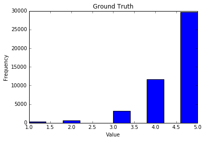

```python
plt.hist(finaldf['Rating'].as_matrix())
plt.title("Ground Truth")
plt.xlabel("Value")
plt.ylabel("Frequency")
fig = plt.gcf()
```

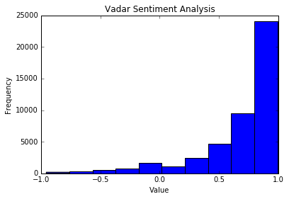

```python
plt.hist(finaldf['vader'].as_matrix())
plt.title("Vadar Sentiment Analysis")
plt.xlabel("Value")
plt.ylabel("Frequency")
fig = plt.gcf()
```

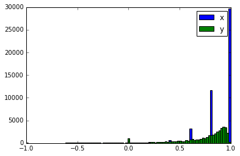

```python
#Overlayed Histogram for GT rating and VD score
import numpy
from matplotlib import pyplot
#Just for demonstrating, I am dividing the rating score by 5
x = [finaldf['Rating'].as_matrix()/5]
y = [finaldf['vader'].as_matrix()]
bins = numpy.linspace(-1, 1, 100)
pyplot.hist(x, bins, label='x')
pyplot.hist(y, bins, label='y')
pyplot.legend(loc='upper right')
pyplot.show()
```

```python
tpdf = pd.DataFrame(topkPos)
tndf = pd.DataFrame(topkNeg)
tpdf.columns =['word','freq']
tndf.columns =['word','freq']
overlayhist = pd.merge(tpdf, tndf, on=['word'])
overlayhist
```

|  | word | freq_x | freq_y |
| --- | --- | --- | --- |
| 0 | great | 9779 | 559 |
| 1 | visit | 7324 | 606 |
| 2 | place | 6717 | 589 |
| 3 | time | 6202 | 550 |

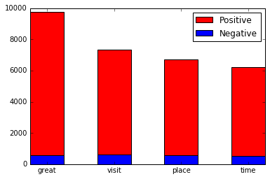

```python
word = overlayhist['word']
counts = overlayhist['freq_x']
# Plot stacked bar chart using matplotlib bar().
indexes = np.arange(len(word))
width = 0.5
p1 = plt.bar(indexes, counts, width, color='r')
word = overlayhist['word']
counts = overlayhist['freq_y']
indexes = np.arange(len(word))
width = 0.5
p2 = plt.bar(indexes, counts, width, color='b')
plt.xticks(indexes + width * 0.5, word)
plt.legend((p1[0], p2[0]), ('Positive', 'Negative'))
```